# Healthcare Systems and COVID-19

Trey Schulman

5/9/2020

## Background and Question

As COVID-19 continues to spread and take lives, there’s an interest in what determines how severely a country is hit. There’s a particularly large emphasis on government and societal responses and how these measures have limited Coronavirus deaths. The strength of these measures is perhaps the best indicator of Coronavirus’s severity for a given country, and as a result this has been among the most debated and studied. This is increasingly the case as world leaders utilize data to evaluate their own responsiveness. However, I’m interested in whether the quality and size of a country’s healthcare system is a determining factor in a country’s Coronavirus deaths per capita. This analysis is then less interested in a government’s preparedness and response, and instead focuses solely on the healthcare system for each respective country. For this evaluation I primarily am interested in wealthier/larger countries since they have more resources to expend on healthcare if they so choose. These countries also typically have more accurate data on Coronavirus due to increased testing capacity. Many of these countries have also already taken the brunt of Coronavirus by this point. The main healthcare data that will be used primarily contains information on how much a country spends on healthcare and how many medical professionals they have. So, my main question is how accurately can you classify a country’s death toll using only information on its healthcare system.

## Data Tidying

I had to use two datasets in order to show a relationship between healthcare systems and Coronavirus deaths. [“total_deaths_per_million.csv”](https://www.kaggle.com/danevans/world-bank-wdi-212-health-systems/data) essentially contains the response variable of deaths/million for each country, and [“2.12_Health_systems.csv”](https://github.com/owid/covid-19-data) contains the predictor variables relating to a country’s healthcare system. These features include public/private spending on healthcare and hospital staff numbers. So, in this section I had to clean up the data a little and then merge the two datasets.

```r
# data on countries' health care systems
world_health <- read.csv("2.12_Health_systems.csv")
# data on every country's cumulative deaths up to each date
all_deaths <- read.csv("total_deaths_per_million.csv")
# data from up to May 6th deaths per million for every country
deaths <- all_deaths[128, ]

# need to select countries that want to analyze
# had to make two lists because of slightly different naming conventions in two datasets
countries <- c("Italy", "France", "Germany", "United.Kingdom", "United.States", "Canada", "Japan", "South.Korea", "Norway", "Switzerland", "Sweden", "Netherlands", "Spain", "Austria", "Singapore", "Denmark", "Australia", "Finland", "Belgium", "Portugal")
countries1 <- c("Italy", "France", "Germany", "United Kingdom", "United States", "Canada", "Japan", "Korea, Rep.", "Norway", "Switzerland", "Sweden", "Netherlands", "Spain", "Austria", "Singapore", "Denmark", "Australia", "Finland", "Belgium", "Portugal")

# selecting/filtering the two datasets for only the countries we want
health_country <- filter(world_health, world_health$World_Bank_Name %in% countries1)
country_deaths <- select(deaths, countries)
```

```
## Note: Using an external vector in selections is ambiguous.
## ℹ Use `all_of(countries)` instead of `countries` to silence this message.
## ℹ See <https://tidyselect.r-lib.org/reference/faq-external-vector.html>.
```

```r
# changing data from wide to long format
country_deaths <- t(country_deaths)

# more tidying and small changes so that I can merge the two datasets
colnames(country_deaths) <- "Deaths_per_million"
country_deaths <- as.data.frame(country_deaths)
setDT(country_deaths, keep.rownames = "Country")[]
country_deaths[5, 1] <- "United States"
country_deaths[4, 1] <- "United Kingdom"
country_deaths[8, 1] <- "Korea, Rep."

# merging the two datasets
data_covid <- merge(country_deaths, health_country, by.x = "Country", by.y="World_Bank_Name")
```

## Exploratory Data Analysis

Now that we’ve cleaned and made our dataset we can determine what features stand out and what’s important.

```r
View(data_covid)
```

There are some columns with repeated info in the new merged dataset. There are also columns where all the values are the same and won’t help to differentiate between countries, so we want to drop these columns.

```r
drop_columns(data_covid, c("Province_State", "Country_Region",
                     "Completeness_of_birth_reg_2009.18", "Completeness_of_death_reg_2008.16",
                     "External_health_exp_pct_2016"))
```

Now we want to look at statistics describing the dataset.

```r
introduce(data_covid)
```

```
##    rows columns discrete_columns continuous_columns all_missing_columns
## 1:   20      10                1                  9                   0
##    total_missing_values complete_rows total_observations memory_usage
## 1:                    0            20                200         6456
```

Let’s look at a correlation heatmap to see which variables are correlated with the response variable “Deaths_per_million.”

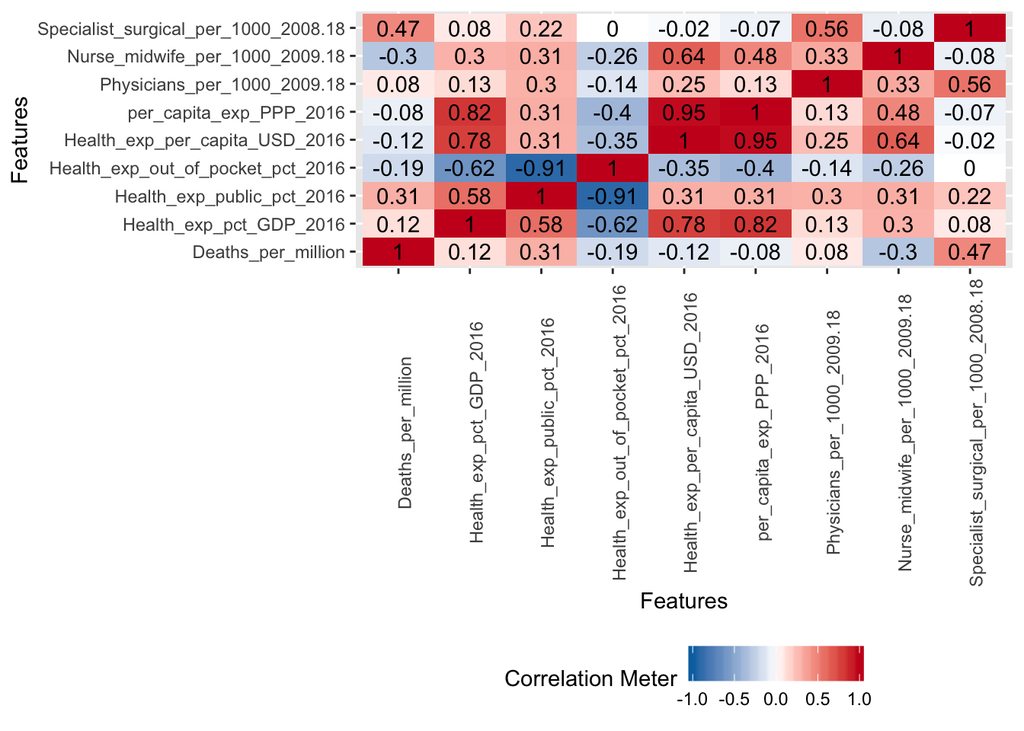

```r
plot_correlation(data_covid,
                 type = "continuous")
```

We can see that many of our variables have little to no correlation with “Deaths_per_million” and likely won’t be helpful with any analysis. The strongest correlation is from “Specialist_surgical_per_1000_2008.18” at 0.47 and this represents how many specialist surgical providers per 1000 people are in each country. “Health_exp_public_pct_2016” has the second highest correlation of 0.31 and represents the share of current health expenditures funded from domestic public sources for health. “Nurse_midwife_per_1000_2009.18” has correlation of -0.3 and measures nurses and midwives per 1000 people. Other variables with an absolute correlation value above 0.1 that may be useful are “Health_exp_out_of_pocket_pct_2016” (-0.19) which measures the share of out-of-pocket payments of total current health expenditures, “Health_exp_pct_GDP_2016” (0.12) which measures current health expenditure expressed as a percentage of GDP, and “Health_exp_per_capita_USD_2016” (-0.12) which measures expenditures on health per capita.

Now let’s visualize the relationship between some of the more correlated predictors and the response variable. We can plot the data points for each predictor relating to the response variable and then also add in a regression line with a standard error confidence band.

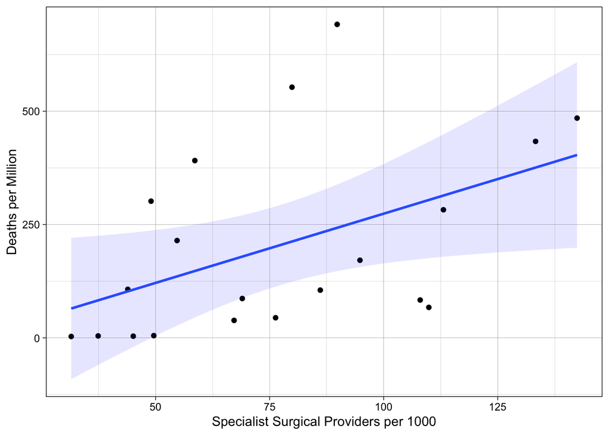

```r
ggplot(data = data_covid,
       aes(x=Specialist_surgical_per_1000_2008.18,
           y= Deaths_per_million)) +
  geom_point() +
  geom_smooth(method=lm, alpha=0.1, fill = "blue") +
  labs(y= "Deaths per Million", x= "Specialist Surgical Providers per 1000") +
  theme_linedraw()
```

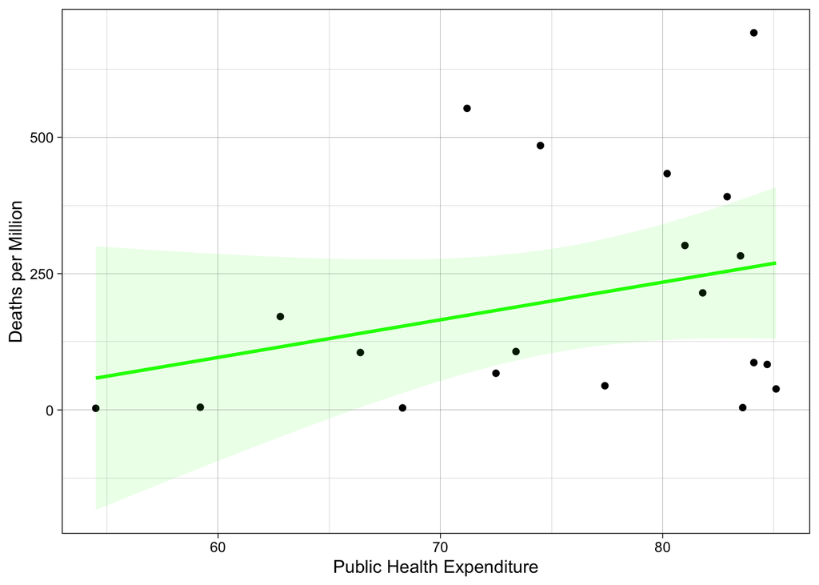

```r
ggplot(data = data_covid,
       aes(x= Health_exp_public_pct_2016,
           y= Deaths_per_million)) +
  geom_point() +
  geom_smooth(method=lm, alpha=0.1, fill = "green", color= "green") +
  labs(y= "Deaths per Million", x= "Public Health Expenditure") +
  theme_linedraw()
```

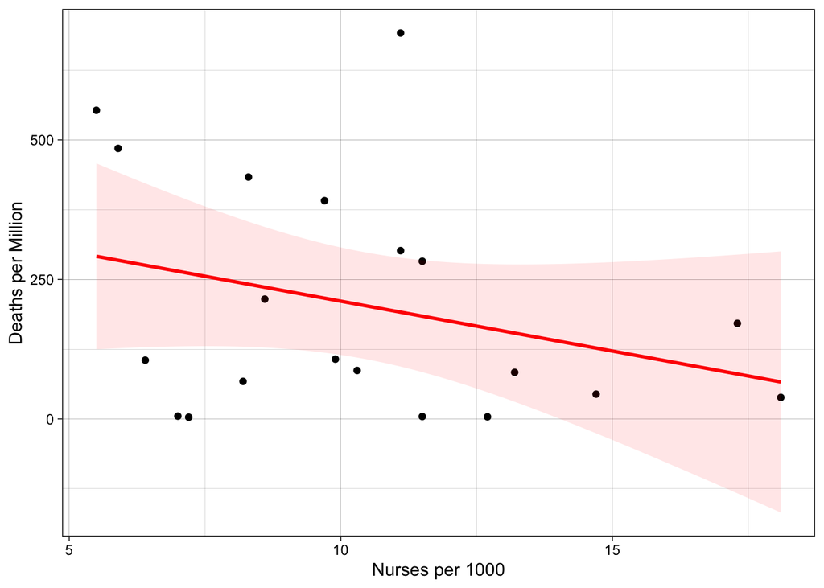

```r
ggplot(data = data_covid,
       aes(x=Nurse_midwife_per_1000_2009.18,
           y= Deaths_per_million)) +
  geom_point() +
  geom_smooth(method=lm, alpha=0.1, fill = "red", color="red") +
  labs(y= "Deaths per Million", x= "Nurses per 1000") +
  theme_linedraw()
```

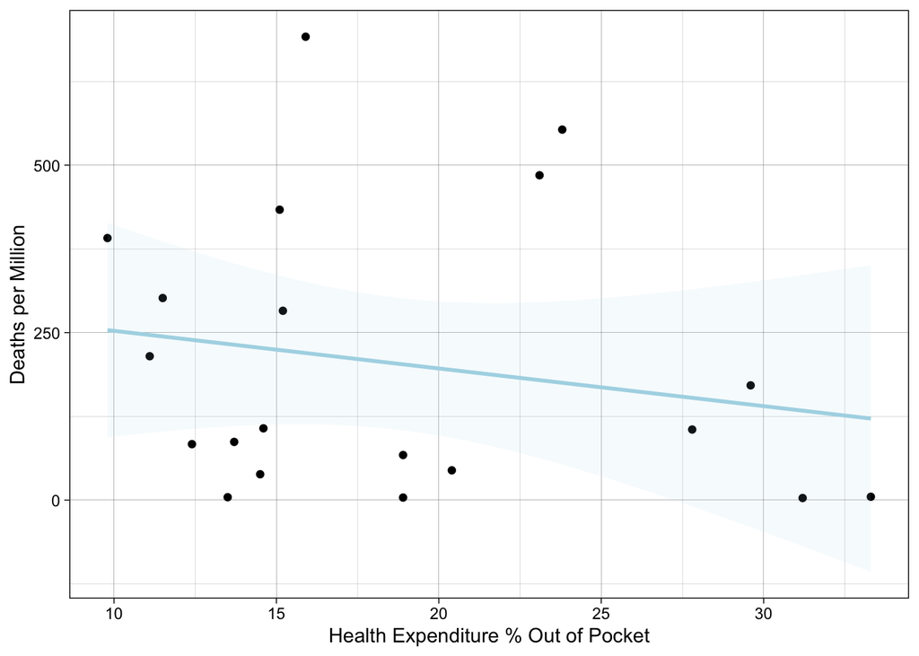

```r
ggplot(data = data_covid,
       aes(x=Health_exp_out_of_pocket_pct_2016,
           y= Deaths_per_million)) +
  geom_point() +
  geom_smooth(method=lm, alpha=0.1, fill = "lightblue", color="lightblue") +
  labs(y= "Deaths per Million", x= "Health Expenditure % Out of Pocket") +
  theme_linedraw()
```

These visualizations largely match what was expected from our correlation heatmap, as the strength of our linear relationships line up with the strength of our correlations. Also as expected most of these linear relationships are fairly weak.

## Methods

So, now we know which features may have an impact on classifying a country’s deaths per million from Coronavirus. Now it’s time to actually determine how accurately these features can classify a country’s deaths per million. For this classification task, I’m going to use K Nearest Neighbors due to all of the data being continuous and that we don’t have too many important predictors to include, so calculating distance won’t be too slow. I’m going to have to refactor “Deaths_per_million” because it’s continuous and we need to classify a country’s death rate based on its other healthcare factors. Therefore, I’m going to break up countries above the dataset’s death rate median as “High” and those below it as “Low.” This will give us a base rate of 50% for correctly classifying a country. The data also needs to be scaled for kNN.

```r
drop_columns(data_covid, "Country") # need to remove discrete variables to scale
scaled_covid <- as.data.frame(scale(data_covid[], center = TRUE, scale = TRUE)) # scale our data
med <- median(scaled_covid$Deaths_per_million)
scaled_covid$Deaths_per_million[scaled_covid$Deaths_per_million > med] <- 1 # 1 = High Rate
scaled_covid$Deaths_per_million[scaled_covid$Deaths_per_million < med] <- 0 # 0 = Low Rate
```

The data now needs to be split into training and testing data, so that we can determine the accuracy of the model. Then we can make our kNN classifier.

```r
set.seed(1998)
covid_train_rows = sample(1:20, round(0.7 * 20, 0), replace = FALSE) # 70/30 split for train/test
covid_train <- scaled_covid[covid_train_rows, ]  #select training data
covid_test <- scaled_covid[-covid_train_rows, ]

covid_5NN <-  knn(train = covid_train[, c("Specialist_surgical_per_1000_2008.18", #build our model
                                          "Health_exp_public_pct_2016",
                                          "Nurse_midwife_per_1000_2009.18",
                                          "Health_exp_out_of_pocket_pct_2016")],
               test = covid_test[, c("Specialist_surgical_per_1000_2008.18",
                                          "Health_exp_public_pct_2016",
                                          "Nurse_midwife_per_1000_2009.18",
                                          "Health_exp_out_of_pocket_pct_2016")],
               cl = covid_train[, "Deaths_per_million"],
               k = 5,
               use.all = TRUE,
               prob = TRUE)

con_matrix = table(covid_5NN,
                covid_test$Deaths_per_million) #make confusion matrix for our results

kNN_acc = sum(con_matrix[row(con_matrix) == col(con_matrix)]) / sum(con_matrix) #determine our accuracy
kNN_acc # 0.5
```

```
## [1] 0.5
```

After creating the appropriate training and testing datasets I was able to build my kNN model. I tuned my model to acheive the highest possible accuracy by testing all possible variations of the hyperparameters. I tested every different k and combination of predictor variables. The highest accuracy was acheived with the 4 strongest features and k = 5. However, this highest acheivable accuracy is still only 50%, which is equal to the original base rate.

## Conclusions

With a classification accuracy rate equal to the base rate, we are not able to conclude that this data describing a country’s healthcare system makes a difference in their COVID-19 death rate. This result is not altogether surprising considering that the most important detractors of Coronavirus have been testing capacity, hospital beds, ventilators, and social restrictions, and none of these are directly quanitified in this dataset. All of these features are also more of a result of a country’s response than anything else. It still wouldn’t have been improbable for the quality of a country’s healthcare system to predict a country’s response, though. However, the takeaways from the initial exploratory data analysis made it seem doubtful that classification would succeed in this case. First of all, most of the features had little to no correlation with Deaths/million, and it was surprising that how much a government spends on healthcare had almost no relationship. It also was paradoxical that the more specialist surgical professionals a country had, then the more Coronavirus deaths they had. Therefore, even if classification had proven successful there were some major logical flaws in our data.

## Future Work

I still believe it’s probable that the quality of a country’s healthcare system has an impact on Coronavirus deaths. I think it’s likely that we just need different metrics to measure a country’s healthcare system than the ones used in this dataset. The main limitation in this analysis, though, may just be problems with Coronavirus data reporting. For example, not all of the countries chosen are in the same stage of this pandemic, and deaths are still increasing. This is partially why I only chose these 20 countries was to minimize these differences, but they still exist. I obviously would’ve liked to include more countries, but I was hesitant to include countries with known [problems](https://www.nytimes.com/2020/04/02/us/politics/cia-coronavirus-china.html) relating to Coronavirus data reporting. For this reason, I believe that the best analysis on this relationship will have to wait at least until we exit this pandemic.